# Peer_graded_Assignment2

Toru Hasegawa

2019/6/1

# The Worst Weather Event for Population Health and Economic

## Synopsis

In this assignment, I analyze [Storm Data](https://d396qusza40orc.cloudfront.net/repdata%2Fdata%2FStormData.csv.bz2) based on the [National Weather Service Storm Data](https://d396qusza40orc.cloudfront.net/repdata%2Fpeer2_doc%2Fpd01016005curr.pdf).

And the subject of this analysis is clearing up following point, 1. What type of event is the worst for population health 2. What type of event is the worst for economic

## Data Processing

```r
download.file("https://d396qusza40orc.cloudfront.net/repdata%2Fdata%2FStormData.csv.bz2",destfile = "Stome_data.bz2")
```

```r
storm_data <- read.csv("Stome_data.csv.bz2")

head(storm_data)
```

```
##   STATE__           BGN_DATE BGN_TIME TIME_ZONE COUNTY COUNTYNAME STATE
## 1       1  4/18/1950 0:00:00     0130       CST     97     MOBILE    AL
## 2       1  4/18/1950 0:00:00     0145       CST      3    BALDWIN    AL
## 3       1  2/20/1951 0:00:00     1600       CST     57    FAYETTE    AL
## 4       1   6/8/1951 0:00:00     0900       CST     89    MADISON    AL
## 5       1 11/15/1951 0:00:00     1500       CST     43    CULLMAN    AL
## 6       1 11/15/1951 0:00:00     2000       CST     77 LAUDERDALE    AL
##    EVTYPE BGN_RANGE BGN_AZI BGN_LOCATI END_DATE END_TIME COUNTY_END
## 1 TORNADO         0                                               0
## 2 TORNADO         0                                               0
## 3 TORNADO         0                                               0
## 4 TORNADO         0                                               0
## 5 TORNADO         0                                               0
## 6 TORNADO         0                                               0
##   COUNTYENDN END_RANGE END_AZI END_LOCATI LENGTH WIDTH F MAG FATALITIES
```

[output cut: 20 more lines]

```r
columnlist <- c("EVTYPE", "FATALITIES", "INJURIES","PROPDMG","PROPDMGEXP", "CROPDMG","CROPDMGEXP")
df <- storm_data[,columnlist]

summary(df)
```

```
##                EVTYPE         FATALITIES          INJURIES
##  HAIL             :288661   Min.   :  0.0000   Min.   :   0.0000
##  TSTM WIND        :219940   1st Qu.:  0.0000   1st Qu.:   0.0000
##  THUNDERSTORM WIND: 82563   Median :  0.0000   Median :   0.0000
##  TORNADO          : 60652   Mean   :  0.0168   Mean   :   0.1557
##  FLASH FLOOD      : 54277   3rd Qu.:  0.0000   3rd Qu.:   0.0000
##  FLOOD            : 25326   Max.   :583.0000   Max.   :1700.0000
##  (Other)          :170878
##     PROPDMG          PROPDMGEXP        CROPDMG          CROPDMGEXP
##  Min.   :   0.00          :465934   Min.   :  0.000          :618413
##  1st Qu.:   0.00   K      :424665   1st Qu.:  0.000   K      :281832
##  Median :   0.00   M      : 11330   Median :  0.000   M      :  1994
##  Mean   :  12.06   0      :   216   Mean   :  1.527   k      :    21
##  3rd Qu.:   0.50   B      :    40   3rd Qu.:  0.000   0      :    19
##  Max.   :5000.00   5      :    28   Max.   :990.000   B      :     9
##                    (Other):    84                     (Other):     9
```

```r
table(is.na(df))
```

```
##
##   FALSE
## 6316079
```

```r
#The dataset don't have NA data.
```

## Results

1. Across the United States, which types of events (as indicated in the EVTYPE variable) are most harmful with respect to population health?

```r
FatalitiesPerEvtype <- aggregate(FATALITIES~EVTYPE, df, FUN=sum)
InjuriesPerEvtype <-aggregate(INJURIES~EVTYPE, df, FUN=sum)

#Search the most harmful event for health
FatalitiesPerEvtype$EVTYPE[which.max(FatalitiesPerEvtype$FATALITIES)]
```

```
## [1] TORNADO
## 985 Levels:    HIGH SURF ADVISORY  COASTAL FLOOD ... WND
```

```r
InjuriesPerEvtype$EVTYPE[which.max(InjuriesPerEvtype$INJURIES)]
```

```
## [1] TORNADO
## 985 Levels:    HIGH SURF ADVISORY  COASTAL FLOOD ... WND
```

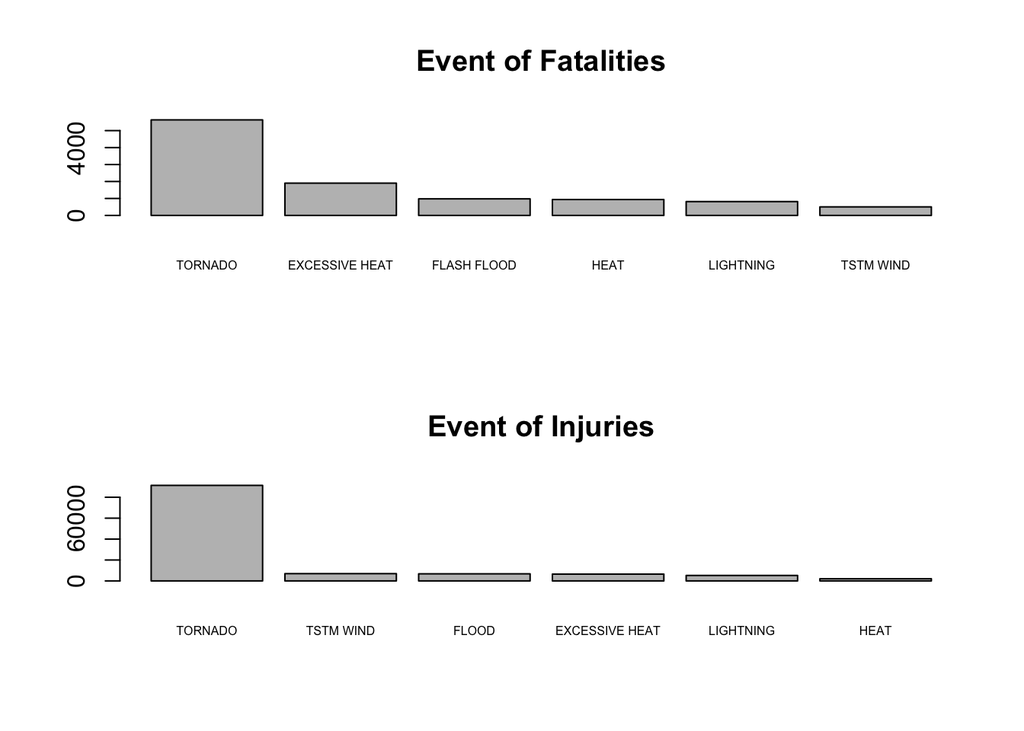

```r
#make barplot of top6 harmful event
sort <- order(FatalitiesPerEvtype$FATALITIES, decreasing = TRUE)
Ordered_Fatalities <- FatalitiesPerEvtype[sort,]
sort2 <- order(InjuriesPerEvtype$INJURIES, decreasing = TRUE)
Ordered_Injuries <- InjuriesPerEvtype[sort2,]

par(mfrow=c(2,1))
barplot(head(Ordered_Fatalities$FATALITIES), names.arg = head(Ordered_Fatalities$EVTYPE), cex.names = 0.5, main="Event of Fatalities")
barplot(head(Ordered_Injuries$INJURIES), names.arg = head(Ordered_Injuries$EVTYPE), cex.names = 0.5, main="Event of Injuries")
```

As result, the top of harmful event to population health is “TORNADO”" in both of fatalities and injuries aspect.

2. Across the United States, which types of events have the greatest economic consequences?

```r
summary(df$PROPDMGEXP)
```

```
##             -      ?      +      0      1      2      3      4      5
## 465934      1      8      5    216     25     13      4      4     28
##      6      7      8      B      h      H      K      m      M
##      4      5      1     40      1      6 424665      7  11330
```

```r
summary(df$CROPDMGEXP)
```

```
##             ?      0      2      B      k      K      m      M
## 618413      7     19      1      9     21 281832      1   1994
```

Based on the above results, this data have a lot of metric prefix. Exchange those metric prerfix to number

```r
#exchange crop data
df$CROPDMGEXP <- as.character(df$CROPDMGEXP)
df$CROPDMGEXP[df$CROPDMGEXP == "0" | df$CROPDMGEXP == "2" ] <- "10"
df$CROPDMGEXP[df$CROPDMGEXP == "?" | df$CROPDMGEXP == "" ] <- "0"
df$CROPDMGEXP[df$CROPDMGEXP == "B" ] <- "1000000000"
df$CROPDMGEXP[df$CROPDMGEXP == "m" | df$CROPDMGEXP == "M" ] <- "1000000"
df$CROPDMGEXP[df$CROPDMGEXP == "k" | df$CROPDMGEXP == "K" ] <- "1000"
df$CROPDMGEXP <- as.numeric(df$CROPDMGEXP)
df$CROPDMG2 <- df$CROPDMGEXP * df$CROPDMG

#exchange prop data
df$PROPDMGEXP <- as.character(df$PROPDMGEXP)
df$PROPDMGEXP[df$PROPDMGEXP == "0" | df$PROPDMGEXP == "1" ] <- "10"
df$PROPDMGEXP[df$PROPDMGEXP == "2" | df$PROPDMGEXP == "3" ] <- "10"
df$PROPDMGEXP[df$PROPDMGEXP == "4" | df$PROPDMGEXP == "5" ] <- "10"
df$PROPDMGEXP[df$PROPDMGEXP == "6" | df$PROPDMGEXP == "7" ] <- "10"
df$PROPDMGEXP[df$PROPDMGEXP == "8" ] <- "10"
df$PROPDMGEXP[df$PROPDMGEXP == "?" | df$PROPDMGEXP == "" ] <- "0"
df$PROPDMGEXP[df$PROPDMGEXP == "-" ] <- "0"
df$PROPDMGEXP[df$PROPDMGEXP == "+" ] <- "1"
df$PROPDMGEXP[df$PROPDMGEXP == "B" ] <- "1000000000"
df$PROPDMGEXP[df$PROPDMGEXP == "m" | df$PROPDMGEXP == "M" ] <- "1000000"
df$PROPDMGEXP[df$PROPDMGEXP == "k" | df$PROPDMGEXP == "K" ] <- "1000"
df$PROPDMGEXP[df$PROPDMGEXP == "h" | df$PROPDMGEXP == "H" ] <- "100"
df$PROPDMGEXP <- as.numeric(df$PROPDMGEXP)
df$PROPDMG2 <- df$PROPDMGEXP * df$PROPDMG
```

```r
#prepare dataset to make ranking
prop_sum <- aggregate(PROPDMG2~EVTYPE, df,FUN=sum)

#Search the worst event for prop
sort3 <- order(prop_sum$PROPDMG2, decreasing = TRUE)
Ordered_prop_sum <- prop_sum[sort3,]
head(Ordered_prop_sum)
```

```
##                EVTYPE     PROPDMG2
## 170             FLOOD 144657709800
## 411 HURRICANE/TYPHOON  69305840000
## 834           TORNADO  56937162897
## 670       STORM SURGE  43323536000
## 153       FLASH FLOOD  16140815011
## 244              HAIL  15732269877
```

```r
#prepare dataset to make ranking
crop_sum <- aggregate(CROPDMG2~EVTYPE, df, FUN=sum)

#Search the worst event for crop
sort4 <- order(crop_sum$CROPDMG2, decreasing = TRUE)
Ordered_crop_sum <- crop_sum[sort4,]
head(Ordered_crop_sum)
```

```
##          EVTYPE    CROPDMG2
## 95      DROUGHT 13972566000
## 170       FLOOD  5661968450
## 590 RIVER FLOOD  5029459000
## 427   ICE STORM  5022113500
## 244        HAIL  3025954650
## 402   HURRICANE  2741910000
```

The top of worst event for crop is “DROUGHT”.

Sum up of those results, and calcurate total economic effect for each event types.

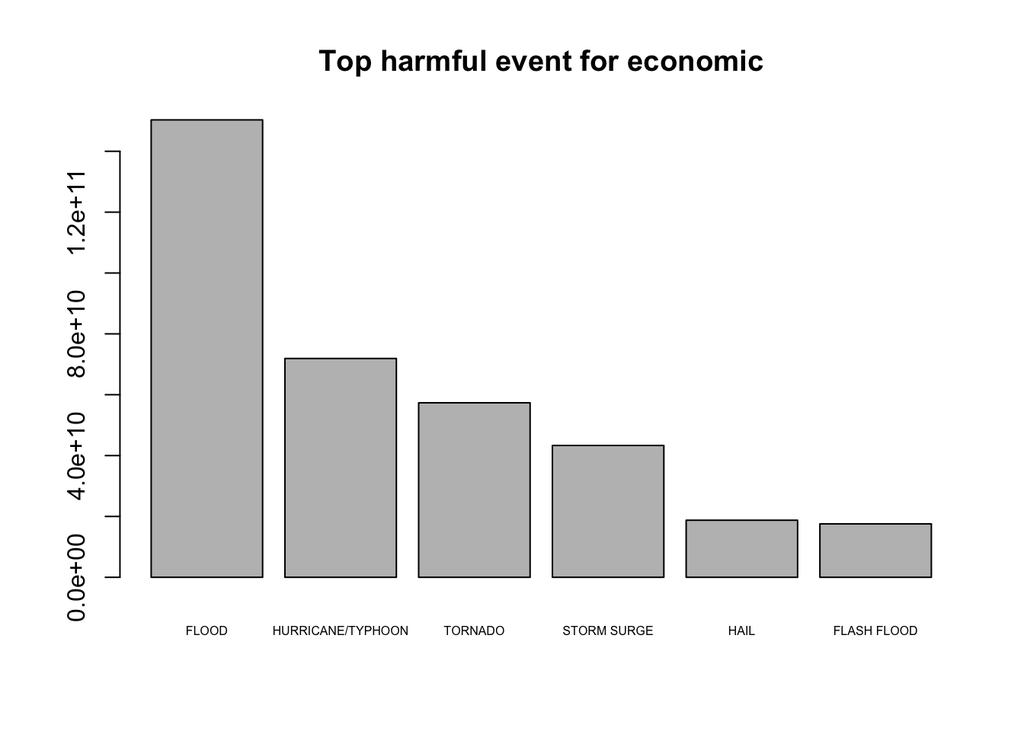

```r
#merge prop and crop data
total_effect <- merge(prop_sum, crop_sum)
total_effect$total_sum <- total_effect$PROPDMG2 + total_effect$CROPDMG2
sort5<- order(total_effect$total_sum, decreasing = TRUE)
Ordered_total_effect <-total_effect[sort5,]

#make barplot
barplot(head(Ordered_total_effect$total_sum), names.arg = head(Ordered_total_effect$EVTYPE), cex.names = 0.5, main="Top harmful event for economic")
```

In conclusion, “FLOOD”is most harmful event for economic.